## MHD Project (in z)

I have to solve for $B_r$ and $B_{\phi}$ in z.(neglect the r derivatives and $\alpha$ term in the induction equation) I'm using the unitless equation which we findout in Assignment-3 Induction equation is following $$\frac{\partial B_r}{\partial t}=-\frac{V_r}{r}\frac{\partial }{\partial r}(r*B_r)+\frac{\partial }{\partial z}(V_z*B_r)-\frac{\partial }{\partial z}(\alpha*B_{\phi})+\eta_t(\frac{\partial }{\partial r}(\frac{\partial }{r \partial r}(r B_{\phi}))+\frac{\partial^2 B_r}{\partial z ^2})$$ $$\frac{\partial B_{\phi}}{\partial t}=-q\Omega B_r-\frac{\partial }{\partial r}(V_r*B_{\phi})+\frac{\partial }{\partial z}(V_z*B_{\phi})-\frac{\partial }{\partial z}(\alpha*B_r)+\eta_t(\frac{\partial }{\partial r}(\frac{\partial }{r \partial r}(r B_{\phi}))+\frac{\partial^2 B_r}{\partial z ^2})$$ Now the equation consider for the task two is (Only in z derivatives are consider and Velocity term is not taken) $$\frac{\partial B_r '}{\partial t'}=-\frac{\partial (\alpha ' B_{\phi}')}{\partial z'}+\frac{\partial^2 B_r'}{\partial z ^{'2}}$$ $$\frac{\partial B_{\phi}'}{\partial t'}=-q\Omega ' B_{r} '+\frac{\partial^2 B_{\phi} '}{\partial z^{'2} }$$ Now take the Dynamo number equation as $$D=-\frac{q\Omega \alpha _0 h^3}{\eta _t^2}$$ which gives under the unitless equation becomes $\alpha$ changes as $\alpha '$=$\alpha$ $ t_0 $ /h (where $t_0=h_0^2/ \eta _t$ ) and the $\Omega$ as $\Omega '$=$\Omega$ *$\frac{h^2}{\eta_t} $ Now the equation consider for the task two is (in unitless form is) $$\frac{\partial B_r '}{\partial t'}=-\frac{\partial (\alpha ' B_{\phi}')}{\partial z'}+\frac{\partial^2 B_r'}{\partial z ^{'2}}$$ $$\frac{\partial B_{\phi}'}{\partial t'}=-q\Omega ' B_{r} '+\frac{\partial^2 B_{\phi} '}{\partial z^{'2} }$$ and using the Dynamo number D $$\frac{\partial B_r '}{\partial t'}=-\frac{\partial (\alpha ' B_{\phi}')}{\partial z'}+\frac{\partial^2 B_r'}{\partial z ^{'2}}$$ $$\frac{\partial B_{\phi}'}{\partial t'}=\frac{D}{\alpha_0 '} B_{r} '+\frac{\partial^2 B_{\phi} '}{\partial z^{'2} }$$

# Task-2

I am solving this equation in z and the D ,$\alpha$ are all function of r only.Therefore its a fixed constant for fixed r.Thus I will keep this values as constant real number which I will change depending upon the value of r.I will try to vary the value of D for which the deacy constant changes its sign from negative to positive(means growth rate).This D value is known as crtical dynamo number.  
Here since in general case of galaxies,$\Omega$ dreceases with r.So,q>0 and the D < 0 for galaxies.

```python
# importing the required libraries
import math
import numpy as np
import matplotlib.pyplot as plt
from tqdm import tqdm
```

```python
# spatial derivative function using finite difference method

def ddBrdz(B,dz,Nz):
    Br = np.zeros((Nz))
    i=0
    Br[i]=((2*B[i,0])-(5*B[i+1,0])+(4*B[i+2,0])-B[i+3,0])/(dz*dz)
    i=Nz-1
    Br[i]=((2*B[i,0])-(5*B[i-1,0])+(4*B[i-2,0])-B[i-3,0])/(dz*dz)
    for i in range(1,Nz-2):
        #Br[i]=(-B[i-2,0]+16*B[i-1,0]-30*B[i,0]+16*B[i+1,0]-B[i+2,0])/(12*dz*dz)
        Br[i]=(B[i-1,0]+(-2*B[i,0])+B[i+1,0])/(dz*dz)
    return Br
def dBrdz(B,dz,Nz):
    Br = np.zeros((Nz))
    i=0
    Br[i]=(4*B[i+1,0]-B[i+2,0]-3*B[i,0])/(2*dz)
    i=Nz-1
    Br[i]=(-4*B[i-1,0]+B[i-2,0]+3*B[i,0])/(2*dz)
    for i in range(1,Nz-2):
        Br[i]=(B[i+1,0]-B[i-1,0])/(2*dz)
    return Br

def ddBphidz(B,dz,Nz):
    Bphi = np.zeros((Nz))
    i=0
    Bphi[i]=((2*B[i,1])-(5*B[i+1,1])+(4*B[i+2,1])-B[i+3,1])/(dz*dz)
    i=Nz-1
    Bphi[i]=((2*B[i,1])-(5*B[i-1,1])+(4*B[i-2,1])-B[i-3,1])/(dz*dz)
    for i in range(1,Nz-2):
        #Bphi[i]=(-B[i-2,1]+16*B[i-1,1]-30*B[i,1]+16*B[i+1,1]-B[i+2,1])/(12*dz*dz)
        Bphi[i]=(B[i-1,1]+(-2*B[i,1])+B[i+1,1])/(dz*dz)
    return Bphi

def dBphidz(B,dz,Nz):
    Bphi = np.zeros((Nz))
    i=0
    Bphi[i]=(4*B[i+1,1]-B[i+2,1]-3*B[i,1])/(2*dz)
    i=Nz-1
    Bphi[i]=(-4*B[i-1,1]+B[i-2,1]+3*B[i,1])/(2*dz)
    for i in range(1,Nz-2):
        Bphi[i]=(B[i+1,1]-B[i-1,1])/(2*dz)
    return Bphi
def dfdz(f,dz,Nz):
    Br = np.zeros((Nz))
    i=0
    Br[i]=((2*f[i])-(5*f[i+1])+(4*f[i+2])-f[i+3])/(dz*dz)
    i=Nz-1
    Br[i]=((2*f[i])-(5*f[i-1])+(4*f[i-2])-f[i-3])/(dz*dz)
    for i in range(1,Nz-2):
        #Br[i]=(-B[i-2,0]+16*B[i-1,0]-30*B[i,0]+16*B[i+1,0]-B[i+2,0])/(12*dz*dz)
        Br[i]=(f[i-1]+(-2*f[i])+f[i+1])/(dz*dz)
    #print(Br)
    return Br
```

```python
# dB_r/dt=f1()
# dB_phi/dt=f2()
def alphafn(r):
    return (-1)
def f1(B,z,D,alpha,dz,Nz):
    return (ddBrdz(B,dz,Nz)-dfdz(alpha*alphafn(z)*B[:,1],dz,Nz))
def f2(B,z,D,alpha,dz,Nz):
    return (ddBphidz(B,dz,Nz)+((D/alpha)*B[:,0]))
```

```python
#We use the unitless calculations
#Here so in unitless equation  qΩ = - D/α
# α_0 the amplitude of the α effect and D is the dynamo number (q > 0 if Ω decreases with r, which is generally the case in galaxies, so D < 0.)

T = 5.0  # Total simulation time with respect to t_f
Nz = 101  # Number of spatial grid points
Nt = 20000  # Number of time steps
z_i = 0.0  # start of spatial region in z
z_f = 2.0  # end of spatial domain in z
dz = (z_f - z_i) / (Nz - 1)  # Spatial step size
dt = T / Nt  # Time step size


# creating the mesh of z (discetizing the z axis within our region with each distance as dx)
z = np.linspace(z_i, z_f, Nz)
t = np.linspace(0, T, Nt+1)
# Now creating the B array with first component is z position value and second compenent is defingin the r (0),phi(1) and intial we make this zero array values
B = np.zeros((Nz, 2))
#B[:,0] is Br component value
#B[:,1] is Bphi component value
```

```python
# Now applying the Intial values for the B_r0 and B_phi0

def intials():
    def B_phi0(r, phi, z):
        return (np.sin((np.pi * z) / 2.0))

    def B_r0(r, phi, z):
        return ((np.sin((np.pi * z) / 2.0))+(np.sin((np.pi * z)))+1/2*np.sin(4*(np.pi * z)))
    # B_r- intial values are
    B[:, 0] = B_r0(0, 0, z)
    # B_phi- intial values are
    B[:, 1] = B_phi0(0,0,z)

#Boundary condition
a=0  #B_r at Z=Z_i
b1=0  #B_r at Z=Z_f
c=0  #B_phi at Z=Z_i
d1=0  #B_phi at Z=Z_f

# Create arrays to store the solution in time
#iterations_to_save=[0,60,600,int(Nt/8),int(Nt/4),int(Nt/2),Nt]
iterations_to_save=[0,int(Nt/20),int(Nt/8),int(Nt/4),int(Nt/2),int(Nt/1.4),Nt]
B_time = np.zeros((Nt+1, 1))
B_pitch=[]
B_list= []

if 0 in iterations_to_save:
    B_list.append(np.copy(B))
```

```python
#def run(B,iterations_to_save,dz,Nz,D,alpha):
def run(B,iterations_to_save,B_list,B_time,B_pitch,dz,Nz,D,alpha):
    intials()
    B_list.clear()
    if 0 in iterations_to_save:
        B_list.append(np.copy(B))

    B_pitch.clear()
    for n in tqdm(range(0, Nt + 1)):
        #Now using Runge-Kutta 4th order integration for B_r in time at z
        Temp= np.zeros((Nz, 2))
        k1 = f1(B,z,D,alpha,dz,Nz)
        k11 = (f2(B,z,D,alpha,dz,Nz))
        Temp[:,0]=k1*dt/2
        Temp[:,1]=k11*dt/2
        k2 = f1(B+Temp,z,D,alpha,dz,Nz)
        k22 = (f2(B+Temp,z,D,alpha,dz,Nz))
        Temp[:,0]=k2*dt/2
        Temp[:,1]=k22*dt/2
        k3 = (f1(B+Temp,z,D,alpha,dz,Nz))
        k33 = (f2(B+Temp,z,D,alpha,dz,Nz))
        Temp[:,0]=k3*dt
        Temp[:,1]=k33*dt
        k4 = (f1(B+Temp,z,D,alpha,dz,Nz))
        k44 = (f2(B+Temp,z,D,alpha,dz,Nz))
        B[:, 0] = B[:, 0] + ((dt / 6.0) * (k1 +( 2 * k2) + (2 * k3) + k4))
        # Runge-Kutta 4th order integration for B_phi in time at  fixed z
        B[:, 1] = B[:, 1] + ((dt / 6.0) * (k11 + (2 * k22) + (2 * k33) + k44))


        B_time[(n)]=np.log10(np.sqrt((np.mean(B[:,0]))**2+(np.mean(B[:,1]))**2))


        #ghost zones on the outer points of Boundary points(Anti Symmetric Ghost Zone)
        B[1,1]=c
        B[Nz-2,0]=b1
        B[1,0]=a
        B[Nz-2,1]=d1
        B[Nz-1,0]=b1-B[Nz-3,0]
        B[Nz-1,1]=d1-B[Nz-3,1]
        B[0,0]=a-B[2,0]
        B[0,1]=c-B[2,1]

        if n in iterations_to_save:
            B_list.append(np.copy(B))
            #B_pitch.append(np.copy(B))
```

```python
# plotting the results
def plot(iterations_to_save,B_list,B_time,B_pitch,Nz):
    m, b = np.polyfit(t, B_time, 1)
    print("The Decay rate is",m*np.log(10))

    fig, ax = plt.subplots(1, 1, figsize=(6, 4))
    for iteration in range(len(iterations_to_save)):
        ax.plot(z[1:Nz-1], B_list[iteration][1:Nz-1, 0], label=f't={iterations_to_save[iteration] * dt:.4f}')
    ax.set_xlabel(r'$z$')
    ax.set_ylabel(r'$B_r$')
    ax.legend()
    plt.show()

    fig, ax = plt.subplots(1, 1, figsize=(6, 4))
    for iteration in range(len(iterations_to_save)):
        ax.plot(z[1:Nz-1], B_list[iteration][1:Nz-1, 1], label=f't={iterations_to_save[iteration] * dt:.4f}')
    ax.set_xlabel(r'$z$')
    ax.set_ylabel(r'$B_{\phi}$')
    ax.legend()
    plt.show()

    plt.plot(t, B_time, ',', t, m*t+b, '--k')
    plt.xlabel('t')
    #plt.ylabel(r'$\log_{10}(\sqrt{B_r^2+B_{\phi}^2}) at\, midpoint\, z\, of\,the\, region$')
    plt.ylabel(r'$\log_{10}(\sqrt{\bar{B}_r^2+\bar{B}_{\phi}^2})$')
    plt.show()

    B_pitch = np.zeros((Nz-1, len(iterations_to_save)))
    for iteration in range(len(iterations_to_save)):
        for i in range(2,Nz-2):
            B_pitch[i,iteration]=np.arctan(B_list[iteration][i, 0]/(10**(-30)+B_list[iteration][i, 1]))

    fig, ax = plt.subplots(1, 1, figsize=(6, 4))
    for iteration in range(len(iterations_to_save)):
        ax.plot(z[0:Nz-1], B_pitch[:,iteration], label=f't={iterations_to_save[iteration] * dt:.4f}')
    ax.set_xlabel(r'$z$')
    ax.set_ylabel(r'$Pitch\, Angle$')
    ax.legend()
    plt.show()


def plot1(B_time):
    m, c = np.polyfit(t, B_time, 1)
    return m*np.log(10)
```

# Example-1

For first example we use the Dynamo number D=-1 and magnitude of $\alpha_0$=1. We get the decay rate as

```
The Decay rate is [-1.02423765]
```

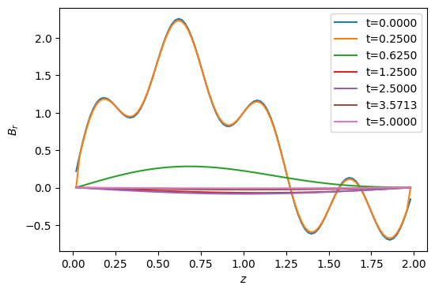

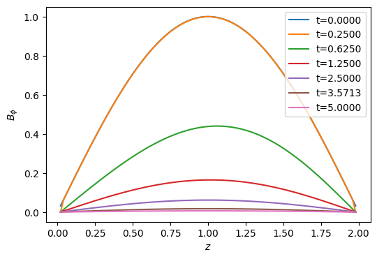

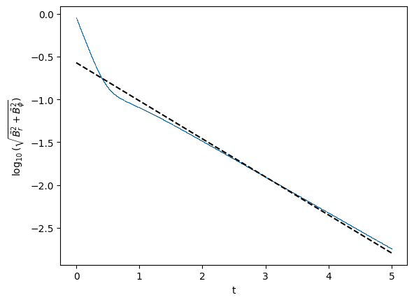

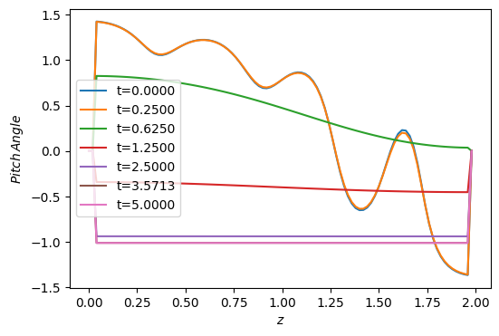

```python
run(B,iterations_to_save,B_list,B_time,B_pitch,dz,Nz,-1,1)
plot(iterations_to_save,B_list,B_time,B_pitch,Nz)
```

# Example-2

For first example we use the Dynamo number D=-5 and magnitude of $\alpha_0$=1 We get the decay rate as

```
The Decay rate is [0.96554052]
```

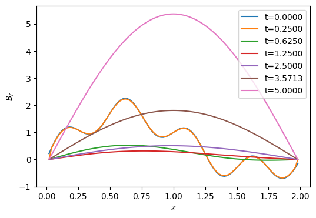

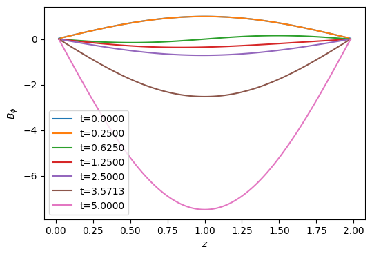

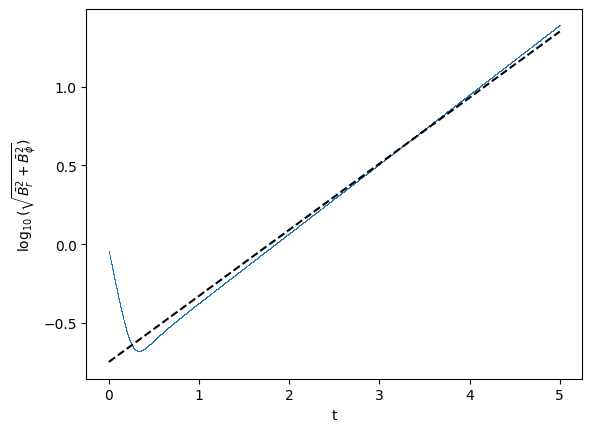

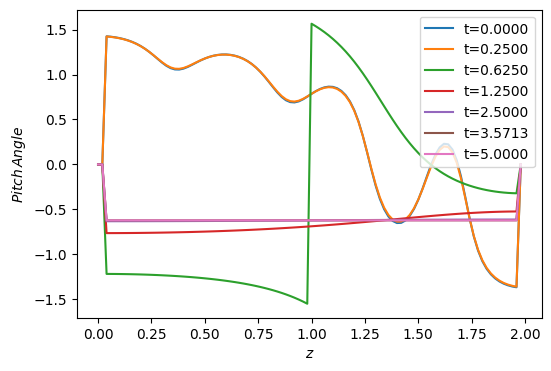

```python
run(B,iterations_to_save,B_list,B_time,B_pitch,dz,Nz,-5,1)
plot(iterations_to_save,B_list,B_time,B_pitch,Nz)
```

# Example-1 with different $\alpha$

For first example again we use the Dynamo number D=-1 and magnitude of $\alpha_0$=5 We get the decay rate as

```
The Decay rate is [-0.8623637]
```

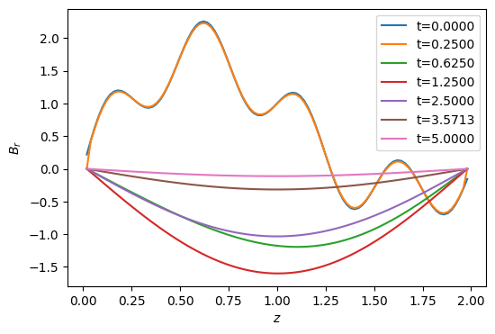

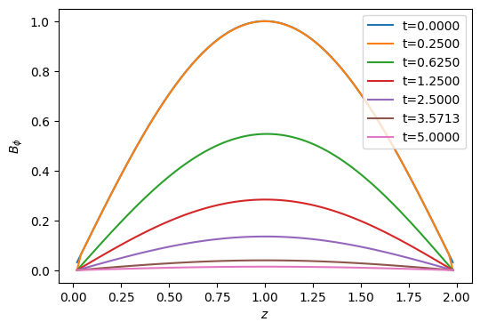

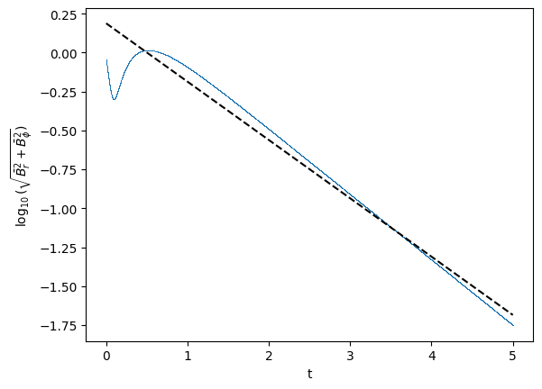

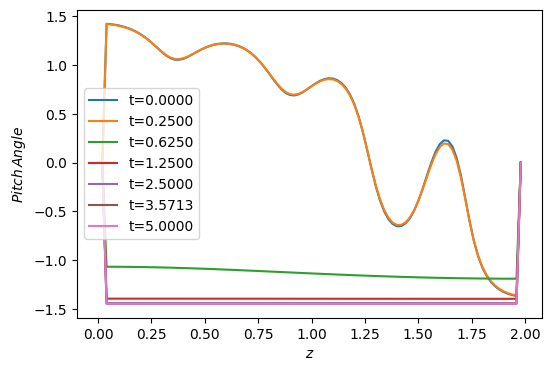

```python
run(B,iterations_to_save,B_list,B_time,B_pitch,dz,Nz,-1,5)
plot(iterations_to_save,B_list,B_time,B_pitch,Nz)
```

# Example-2 with different $\alpha$

For first example again we use the Dynamo number D=-5 and magnitude of $\alpha_0$=5. We get the decay rate as

```
The Decay rate is [1.04745913]
```

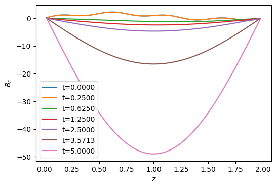

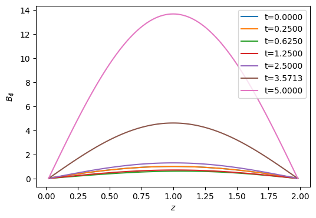

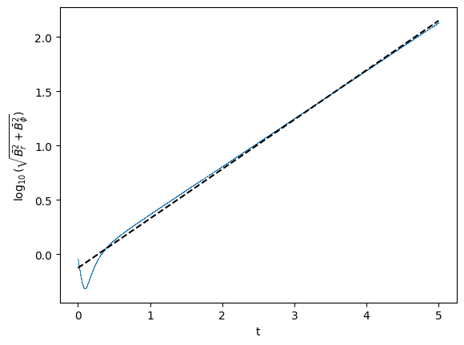

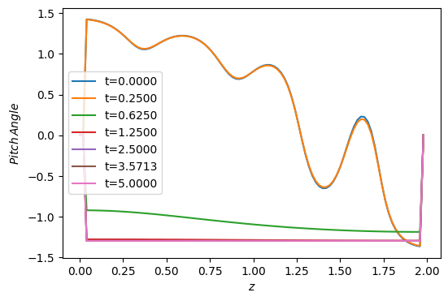

```python
run(B,iterations_to_save,B_list,B_time,B_pitch,dz,Nz,-5,5)
plot(iterations_to_save,B_list,B_time,B_pitch,Nz)
```

# Now we look at large |D|>|D_c| for both the $\alpha$ =1 and 5

Lets take for Example D=-20 and Look at the Decay constant of both cases and Also look close into the Graphs for each one.

```
The Decay rate is [4.61032658]
```

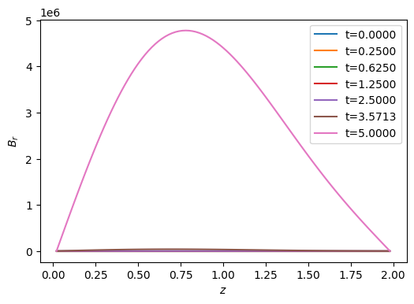

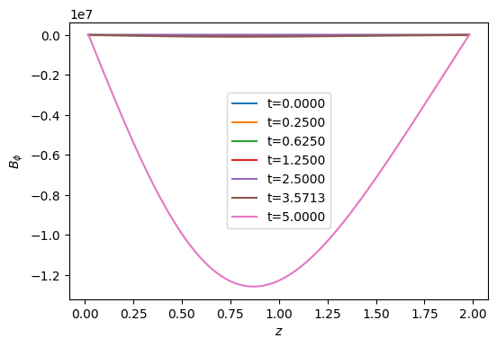

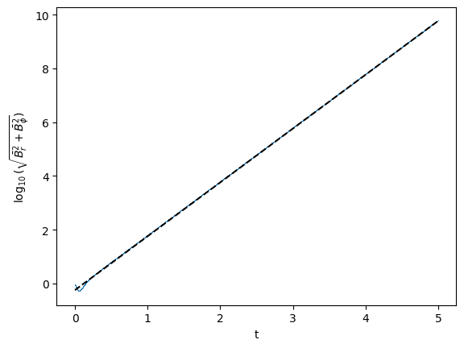

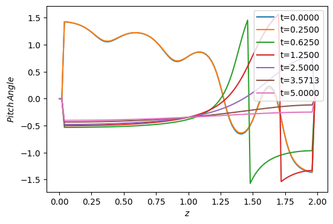

```
The Decay rate is [4.59295435]
```

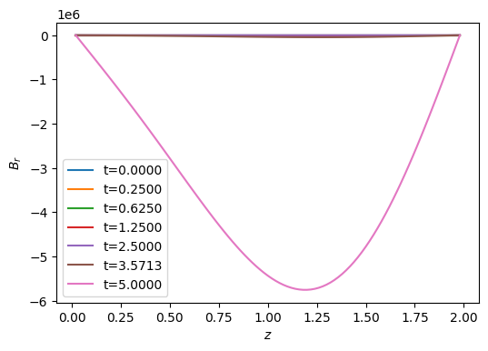

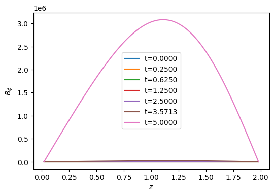

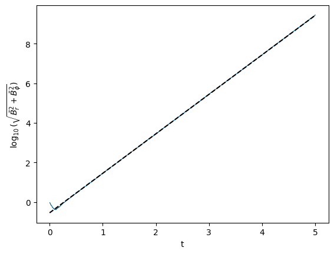

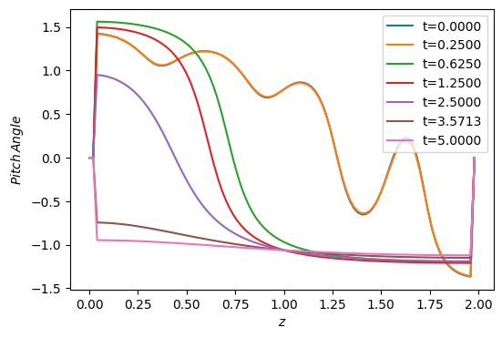

```python
run(B,iterations_to_save,B_list,B_time,B_pitch,dz,Nz,-20,1)
plot(iterations_to_save,B_list,B_time,B_pitch,Nz)
run(B,iterations_to_save,B_list,B_time,B_pitch,dz,Nz,-20,5)
plot(iterations_to_save,B_list,B_time,B_pitch,Nz)
```

# Finding the Critical Dynamo Number

Now we run the automated code for finding the Crtical Dynamo Number (D_c)(that is the D for which the decay rate changes to positive from negative).This we do with error value of D_c is around 0.025.

## Case-1 we take $\alpha$ =1

```python
#Running all the function using different value of D.
alpha=1
d=2
D=0


while d>0.05:  #Here the 0.05 we use is precision we needed for the D_c values we calculate.
    m1=-1 #just to start the loop,we put dummy values
    m2=-1
    print(D)
    while m1<0:
        run(B,iterations_to_save,B_list,B_time,B_pitch,dz,Nz,-D,alpha)
        m1=plot1(B_time)
        print(m1,D) # Here printing the Decay rate for each D value.
        D=D+d
    D=D-2*d
    d=d/2
print("The critical dynamo number numerically is |D_c|=",D+d/2)
```

```
0
```

```
[-2.04272315] 0
```

```
[-0.4977761] 2
```

```
[0.54767296] 4
2
```

```
[-0.4977761] 2
```

```
[-0.01280992] 3.0
```

```
[0.54767296] 4.0
3.0
```

```
[-0.01280992] 3.0
```

```
[0.30018129] 3.5
3.0
```

```
[-0.01280992] 3.0
```

```
[0.15705131] 3.25
3.0
```

```
[-0.01280992] 3.0
```

```
[0.07684628] 3.125
3.0
```

```
[-0.01280992] 3.0
```

```
[0.03348694] 3.0625
The critical dynamo number numerically is |D_c|= 3.015625
```

## Case-2 we take $\alpha$ =5

```python
#Running all the function using different value of D.
alpha=5
d=6
D=0


while d>0.05:
    m1=-1 #just to start the loop,we put dummy values
    m2=-1
    print(D)  #This prints Starting point of D variation.
    while m1<0:
        run(B,iterations_to_save,B_list,B_time,B_pitch,dz,Nz,-D,alpha)
        m1=plot1(B_time)
        print(m1,D) # Here printing the Decay rate for each D value.
        D=D+d
    D=D-2*d
    d=d/2
print("The critical dynamo number numerically is |D_c|=",D+d/2)
```

```
0
```

```
[-1.95909807] 0
```

```
[1.38365144] 6
0
```

```
[-1.95909807] 0
```

```
[0.25815542] 3.0
0.0
```

```
[-1.95909807] 0.0
```

```
[-0.52396752] 1.5
```

```
[0.25815542] 3.0
1.5
```

```
[-0.52396752] 1.5
```

```
[-0.10180825] 2.25
```

```
[0.25815542] 3.0
2.25
```

```
[-0.10180825] 2.25
```

```
[0.08426385] 2.625
2.25
```

```
[-0.10180825] 2.25
```

```
[-0.00708791] 2.4375
```

```
[0.08426385] 2.625
2.4375
```

```
[-0.00708791] 2.4375
```

```
[0.03898662] 2.53125
The critical dynamo number numerically is |D_c|= 2.4609375
```

# Conclusion

From above example,I can see that the with increase with D values the decay constant values increases (from negative higher magnitude value to negative lower magnitude value) and then to become zero and increase the value to be positive.This means at some D value ( we call as Critical Dynamo value $D_c$) the decay of magnetic field becomes the growth of magnetic field exponetially.  
Also with increase in $\alpha$ the $D_c$ value going lower as we can see in above case, where we considered $\alpha$ as 1 and 5.  
For $\alpha$= 1, |$D_c$|=3.015625  
For $\alpha$= 5, |$D_c$|=2.4609375